# ML Homework 1 Guide

1. Save a copy of this ipynb file in your GoogleDrive or PC.
2. Edit the name of this code from "HW1.ipynb" to "HW1_(your name).ipynb"
3. Fill out the code cells below according to descriptions.
4. Save and upload to BrightSpace. (DO NOT clear the outputs of your code)
5. Convert the .ipynb file to PDF file and upload together

# [HW 1-1] Data Indexing

Extract sensor signal (without time column) from 0.02 seconds to 0.12 seconds by indexing the ExampleData in Github.

- Data link: 'https://github.com/purduelamm/purdue_me597_iiot/blob/main/ml_tutorial/ML1/ExampleData?raw=true'
- Index the data as DataFrame format
- Refer to ML1_Code1

```python
# Import the necessary packages
import pandas as pd
import numpy as np

# Load ExampleData from Github
path = "https://github.com/purduelamm/purdue_me597_iiot/blob/main/ml_tutorial/ML1/ExampleData?raw=true"
ExampleData = pd.read_csv(path, sep=',',names=['time(s)', 'Acceleration(g)', 'Voltage(V)', 'Current(kA)'])

# Data indexing
StartPoint = np.where(ExampleData.iloc[:,0] >= 0.02)[0][0]
EndPoint = np.where(ExampleData.iloc[:,0] <= 0.12)[0][-1]


# Define the indexed data as 'SensorData'
SensorData = ExampleData.loc[StartPoint:EndPoint,:].iloc[:,1:]

SensorData
```

|  | Acceleration(g) | Voltage(V) | Current(kA) |
| --- | --- | --- | --- |
| 256 | -0.40050 | 1.6026 | 3.6504 |
| 257 | -0.47753 | 1.5377 | 3.5958 |
| 258 | -0.58822 | 1.4383 | 3.5342 |
| 259 | -0.73779 | 1.3535 | 3.4622 |
| 260 | -0.85521 | 1.2843 | 3.3858 |
| ... | ... | ... | ... |
| 1532 | -0.44388 | 1.7312 | 5.1246 |
| 1533 | -0.43116 | 1.6670 | 5.0836 |
| 1534 | -0.66899 | 1.6050 | 5.0335 |
| 1535 | -0.57326 | 1.5342 | 4.9750 |
| 1536 | -0.72508 | 1.4406 | 4.9062 |

1281 rows × 3 columns

# [HW 1-2] Data Processing & Plotting

- Refer to ML1_Code3

```
(21,)
```

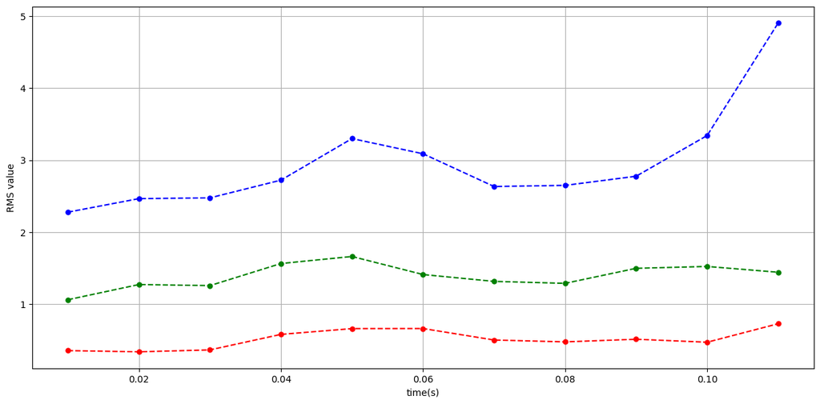

```python
# Import (additional) packages
import matplotlib.pyplot as plt

# Feature extraction
def rms(a):
    return np.sqrt(np.mean(a**2))

RMS_Values = np.zeros((21 , SensorData.shape[1])) # from 0.01 to 0.21 seconds

for sensor in range(SensorData.shape[1]):
    for time in range(21):
        RMS_Values[time,sensor] = rms(SensorData.iloc[128*(time):128*(time+1),sensor])

# Create a time column
TimeArr = np.arange(1,22)/100
print(TimeArr.shape)
TimeArr

# Plot graphs
plt.figure(figsize=(15,7))
plt.plot(TimeArr, RMS_Values[:,0], ls = '--', c = 'r', marker = 'o', ms = 5, mfc = 'r', mec = 'r')
plt.plot(TimeArr, RMS_Values[:,1], ls = '--', c = 'g', marker = 'o', ms = 5, mfc = 'g', mec = 'g')
plt.plot(TimeArr, RMS_Values[:,2], ls = '--', c = 'b', marker = 'o', ms = 5, mfc = 'b', mec = 'b')
plt.grid()
plt.xlabel('time(s)')
plt.ylabel('RMS value')

plt.show()
```

## ML1 and ML2 Summary and Deliverables

Answer the following questions for your achievements

### Q1. Please summarize ML1 and ML2.

ML1 covered data handling and manipulation with the pandas library, plotting with matplotlib, and some indexing and statistics using the numpy library.

ML2 covered the fast fourier transform on a sine function as well as plotting these functions in the frequency domain, culminating in analyzing the sensor data extracted in ML1 on frequency charts.

### Q2. What skills did you have to develop to accomplish this project?

To accomplish this project, I needed to develop analytical skills and learn more about fourier transforms and more specifically the fast fourier transform. In addition, I challenged myself with setting up a local python virtual environment to run all of the code locally.

### Q3. What aspects of this project were the most beneficial for your learning?

Working with an actual dataset to model and represent were the most beneficial for my learning since I was able to see a real world example of how these data analysis tools can be used.

### Q4. What challenges did you encounter in completing the project?

In completing this project, I had a little bit of trouble modifying the code from ML1_3 to work for the homework problem since I was thrown off a little by the modified dataset that did not have the time column.

### Q5. How did you overcome the challenges or remedy the problems encountered?

To overcome this challenge, I needed to analyze the data using a debugger to realize that the code from ML1_3 expected a four column output and had intentional indexing to account for a time column that was not plotted. I changed how the indexing behavior worked so that I would not be getting index errors.